# StrokeData_PCA

## Stroke Dataset - PCA Analysis

In this code we will be running Principal Component Analysis on our dataset in order to reduce dimensionality. This will simplify the complexity of our dataset while still retaining the trends.

Importing all the libraries needed for this code.

```python
import pandas as pd
import matplotlib.pyplot as plt
import numpy as np
from sklearn import decomposition
from sklearn.preprocessing import MinMaxScaler
```

Loading in the dataset.

```python
data = pd.read_csv('healthcare-dataset-stroke-data.csv')
```

There are some missing values in the variable bmi so we are replacing these with the mean of the whole column of bmi values.

```python
data.bmi.fillna(data.bmi.mean(),axis = 0, inplace = True)
```

Creating dummy variables for the dataset.

```python
data_dum = pd.get_dummies(data, dtype = int)
```

```python
data_dum.head()
```

|  | id | age | hypertension | heart_disease | avg_glucose_level | bmi | stroke | gender_Female | gender_Male | gender_Other | ... | work_type_Never_worked | work_type_Private | work_type_Self-employed | work_type_children | Residence_type_Rural | Residence_type_Urban | smoking_status_Unknown | smoking_status_formerly smoked | smoking_status_never smoked | smoking_status_smokes |
| --- | --- | --- | --- | --- | --- | --- | --- | --- | --- | --- | --- | --- | --- | --- | --- | --- | --- | --- | --- | --- | --- |
| 0 | 9046 | 67.0 | 0 | 1 | 228.69 | 36.600000 | 1 | 0 | 1 | 0 | ... | 0 | 1 | 0 | 0 | 0 | 1 | 0 | 1 | 0 | 0 |
| 1 | 51676 | 61.0 | 0 | 0 | 202.21 | 28.893237 | 1 | 1 | 0 | 0 | ... | 0 | 0 | 1 | 0 | 1 | 0 | 0 | 0 | 1 | 0 |
| 2 | 31112 | 80.0 | 0 | 1 | 105.92 | 32.500000 | 1 | 0 | 1 | 0 | ... | 0 | 1 | 0 | 0 | 1 | 0 | 0 | 0 | 1 | 0 |
| 3 | 60182 | 49.0 | 0 | 0 | 171.23 | 34.400000 | 1 | 1 | 0 | 0 | ... | 0 | 1 | 0 | 0 | 0 | 1 | 0 | 0 | 0 | 1 |
| 4 | 1665 | 79.0 | 1 | 0 | 174.12 | 24.000000 | 1 | 1 | 0 | 0 | ... | 0 | 0 | 1 | 0 | 1 | 0 | 0 | 0 | 1 | 0 |

5 rows × 23 columns

Separating the labels into a different dataframe.

```python
labels = data_dum.stroke
```

```python
labels.head()
```

```
0    1
1    1
2    1
3    1
4    1
Name: stroke, dtype: int64
```

Removing the id and stroke variables from the main dataframe. We do not need the id variable and stroke is our labels that we separated into a different dataframe.

```python
data_dum = data_dum.drop(['id','stroke'],axis=1)
```

```python
# reprinting the data frame after removing the id and stroke variables
data_dum.head()
```

|  | age | hypertension | heart_disease | avg_glucose_level | bmi | gender_Female | gender_Male | gender_Other | ever_married_No | ever_married_Yes | ... | work_type_Never_worked | work_type_Private | work_type_Self-employed | work_type_children | Residence_type_Rural | Residence_type_Urban | smoking_status_Unknown | smoking_status_formerly smoked | smoking_status_never smoked | smoking_status_smokes |
| --- | --- | --- | --- | --- | --- | --- | --- | --- | --- | --- | --- | --- | --- | --- | --- | --- | --- | --- | --- | --- | --- |
| 0 | 67.0 | 0 | 1 | 228.69 | 36.600000 | 0 | 1 | 0 | 0 | 1 | ... | 0 | 1 | 0 | 0 | 0 | 1 | 0 | 1 | 0 | 0 |
| 1 | 61.0 | 0 | 0 | 202.21 | 28.893237 | 1 | 0 | 0 | 0 | 1 | ... | 0 | 0 | 1 | 0 | 1 | 0 | 0 | 0 | 1 | 0 |
| 2 | 80.0 | 0 | 1 | 105.92 | 32.500000 | 0 | 1 | 0 | 0 | 1 | ... | 0 | 1 | 0 | 0 | 1 | 0 | 0 | 0 | 1 | 0 |
| 3 | 49.0 | 0 | 0 | 171.23 | 34.400000 | 1 | 0 | 0 | 0 | 1 | ... | 0 | 1 | 0 | 0 | 0 | 1 | 0 | 0 | 0 | 1 |
| 4 | 79.0 | 1 | 0 | 174.12 | 24.000000 | 1 | 0 | 0 | 0 | 1 | ... | 0 | 0 | 1 | 0 | 1 | 0 | 0 | 0 | 1 | 0 |

5 rows × 21 columns

We need to normalize the data in order to run PCA. It is very important to normalize the data before using PCA because an assumption about the model is that the data has a normal distribution and PCA is sensitive to variance of the variables. Large differences between ranges will dominate over small variances if you do not normalize the data.

```python
scaler = MinMaxScaler()
model = scaler.fit(data_dum)
data_norm = model.transform(data_dum)
data_norm[:3]
```

```
array([[0.81689453, 0.        , 1.        , 0.80126489, 0.30126002,
        0.        , 1.        , 0.        , 0.        , 1.        ,
        0.        , 0.        , 1.        , 0.        , 0.        ,
        0.        , 1.        , 0.        , 1.        , 0.        ,
        0.        ],
       [0.74365234, 0.        , 0.        , 0.67902317, 0.21298095,
        1.        , 0.        , 0.        , 0.        , 1.        ,
        0.        , 0.        , 0.        , 1.        , 0.        ,
        1.        , 0.        , 0.        , 0.        , 1.        ,
        0.        ],
       [0.97558594, 0.        , 1.        , 0.23451205, 0.25429553,
        0.        , 1.        , 0.        , 0.        , 1.        ,
        0.        , 0.        , 1.        , 0.        , 0.        ,
        1.        , 0.        , 0.        , 0.        , 1.        ,
        0.        ]])
```

Now running PCA using the sklearn built in model.

```python
pca = decomposition.PCA(n_components=21)
```

```python
# transforming the data
DTtrans = pca.fit(data_norm).transform(data_norm)
np.set_printoptions(precision=2,suppress=True)
print(DTtrans)
```

```
[[-0.55 -0.64  1.12 ...  0.   -0.   -0.  ]
 [-0.73  0.69 -0.53 ... -0.    0.    0.  ]
 [-0.65  0.81  0.85 ...  0.    0.   -0.  ]
 ...
 [-0.63  0.69 -0.57 ...  0.    0.   -0.  ]
 [-0.43  0.77  0.99 ...  0.    0.   -0.  ]
 [-0.06 -0.77 -0.42 ...  0.   -0.    0.  ]]
```

```python
print(pca.explained_variance_ratio_)
```

```
[0.21 0.17 0.16 0.11 0.09 0.06 0.05 0.05 0.03 0.02 0.02 0.01 0.01 0.
 0.   0.   0.   0.   0.   0.   0.  ]
```

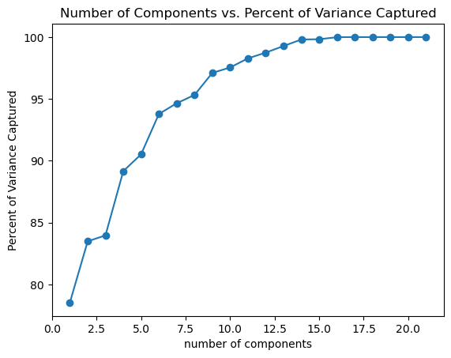

```python
plt.plot(range(1,22), (1-pca.explained_variance_ratio_)*100, marker = 'o')
plt.xlabel('number of components')
plt.ylabel('Percent of Variance Captured')
plt.title('Number of Components vs. Percent of Variance Captured')
plt.show()
```

```python
pc = 0
tot_var = 0
for i in pca.explained_variance_ratio_:
    pc += 1
    tot_var += i*100
    print("Variance captured by Principal Components " + str(pc) + ": " + str(round(tot_var,2)))
```

```
Variance captured by Principal Components 1: 21.47
Variance captured by Principal Components 2: 37.98
Variance captured by Principal Components 3: 54.01
Variance captured by Principal Components 4: 64.85
Variance captured by Principal Components 5: 74.32
Variance captured by Principal Components 6: 80.54
Variance captured by Principal Components 7: 85.89
Variance captured by Principal Components 8: 90.57
Variance captured by Principal Components 9: 93.47
Variance captured by Principal Components 10: 95.92
Variance captured by Principal Components 11: 97.64
Variance captured by Principal Components 12: 98.9
Variance captured by Principal Components 13: 99.62
Variance captured by Principal Components 14: 99.82
Variance captured by Principal Components 15: 99.99
Variance captured by Principal Components 16: 100.0
Variance captured by Principal Components 17: 100.0
Variance captured by Principal Components 18: 100.0
Variance captured by Principal Components 19: 100.0
Variance captured by Principal Components 20: 100.0
Variance captured by Principal Components 21: 100.0
```

Printing the variance captured by each principal component we can see that using 10 principal components we can capture >95% of the variance of the dataset.